# WASH IPD figure and tables

Andrew Mertens

1/3/2021

## Table 1. Prevalence of pathogens by sample type tested in each study

| Study | Sample | Target | Percent positive (n/N) |
| --- | --- | --- | --- |
| Odagiri et al. 2016 | W | V. cholerae | 31.7% (19/60) |
|  | W | Adenovirus | 8.3% (5/60) |
|  | W | Rotavirus | 23.3% (14/60) |
| Boehm et al. 2016 | CH | Rotavirus | 5.7% (28/492) |
|  | S | Rotavirus | 1.4% (7/496) |
|  | W | Rotavirus | 0.6% (3/493) |
| Reese et al. 2017 | SW | Shigella | 10.7% (161/1499) |
|  | SW | V. cholerae | 13% (36/276) |
|  | W | Shigella | 10.1% (190/1874) |
|  | W | V. cholerae | 23.7% (100/422) |
| Steinbaum et al. 2019 | S | Ascaris | 13% (273/2107) |
|  | S | Trichuris | 6.9% (146/2107) |
| Fuhrmeister et al. 2020 | CH | Pathogenic E. coli | 34% (127/373) |
|  | CH | Giardia | 4.8% (15/311) |
|  | CH | Norovirus | 4.2% (14/337) |
|  | MH | Pathogenic E. coli | 24% (177/737) |
|  | MH | Giardia | 2.3% (14/602) |
|  | MH | Norovirus | 3.1% (21/684) |
|  | S | Pathogenic E. coli | 61.3% (453/739) |
|  | W | Pathogenic E. coli | 38.6% (286/741) |
| Holcomb et al. 2020 | S | C. difficile | 14.8% (13/88) |
|  | S | Campylobacter jejuni/coli | 6.8% (6/88) |
|  | S | Salmonella | 6.8% (6/88) |
|  | S | Shigella | 21.6% (19/88) |
|  | S | V. cholerae | 0% (0/88) |
|  | S | Yersinia | 4.5% (4/88) |
|  | S | Ascaris | 60.2% (53/88) |
|  | S | Trichuris | 17% (15/88) |
|  | S | Cryptosporidium | 8% (7/88) |
|  | S | Entamoeba histolytica | 1.1% (1/88) |
|  | S | Giardia | 31.8% (28/88) |
|  | S | Adenovirus | 20.5% (18/88) |
|  | S | Astrovirus | 29.5% (26/88) |
|  | S | Norovirus | 2.3% (2/88) |
|  | S | Rotavirus | 4.5% (4/88) |
|  | S | Sapovirus | 0% (0/88) |
| Kwong et al. 2021 | S | Ascaris | 62.4% (871/1396) |
|  | S | Trichuris | 56.3% (786/1396) |

## Table 2. Prevalence of microbial source tracking markers by sample type tested in each study

| Study | Sample | Target | Percent positive (n/N) |
| --- | --- | --- | --- |
| Odagiri et al. 2016 | W | Animal (BacCow) | 91.7% (55/60) |
|  | W | General (BacUni) | 76.7% (46/60) |
|  | W | Human (Bacteriodes) | 71.7% (43/60) |
| Boehm et al. 2016 | CH | Animal (BacR) | 53.9% (265/492) |
|  | CH | Avian (GFD) | 16.7% (82/492) |
|  | CH | General (GenBac3) | 98.6% (486/493) |
|  | CH | Human (HumM2) | 2.4% (12/492) |
|  | S | Animal (BacR) | 66.7% (331/496) |
|  | S | Avian (GFD) | 33.3% (165/496) |
|  | S | General (GenBac3) | 100% (496/496) |
|  | S | Human (HumM2) | 8.9% (44/496) |
|  | W | Animal (BacR) | 21.9% (108/493) |
|  | W | Avian (GFD) | 9.3% (46/493) |
|  | W | General (GenBac3) | 93.5% (461/493) |
|  | W | Human (HumM2) | 0% (0/493) |
| Fuhrmeister et al. 2020 | CH | Animal (BacCow) | 97.5% (356/365) |
|  | CH | Human (HumM2) | 21.9% (74/338) |
|  | MH | Animal (BacCow) | 96.7% (702/726) |
|  | MH | Human (HumM2) | 18.1% (118/651) |
|  | S | Animal (BacCow) | 90.6% (572/631) |
|  | S | Human (HumM2) | 20.1% (127/631) |
|  | W | Animal (BacCow) | 68.5% (482/704) |
|  | W | Human (HumM2) | 2.6% (17/651) |
| Holcomb et al. 2020 | FP | Avian (GFD) | 0% (0/96) |
|  | FP | Human (M. smithii) | 1.1% (1/94) |
|  | FP | Human (Bacteriodes) | 6.2% (6/96) |
|  | LS | Avian (GFD) | 3.3% (2/60) |
|  | LS | Human (M. smithii) | 45% (27/60) |
|  | LS | Human (Bacteriodes) | 50% (30/60) |
|  | S | Avian (GFD) | 3.6% (3/83) |
|  | S | Human (M. smithii) | 24.1% (20/83) |
|  | S | Human (Bacteriodes) | 42.2% (35/83) |
|  | SW | Avian (GFD) | 0% (0/41) |
|  | SW | Human (M. smithii) | 0% (0/41) |
|  | SW | Human (Bacteriodes) | 2.4% (1/41) |
|  | W | Avian (GFD) | 1.1% (1/94) |
|  | W | Human (M. smithii) | 0% (0/94) |
|  | W | Human (Bacteriodes) | 14.9% (14/94) |

## Primary figures

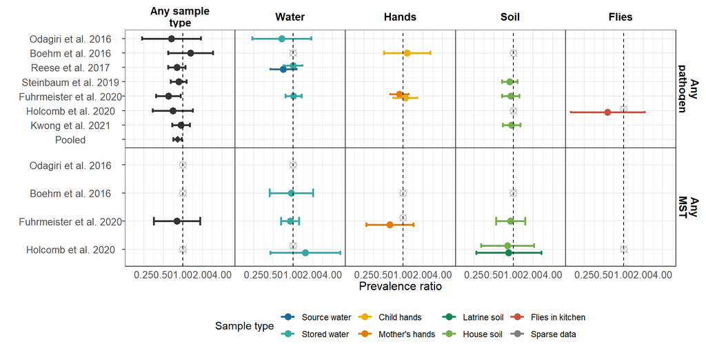

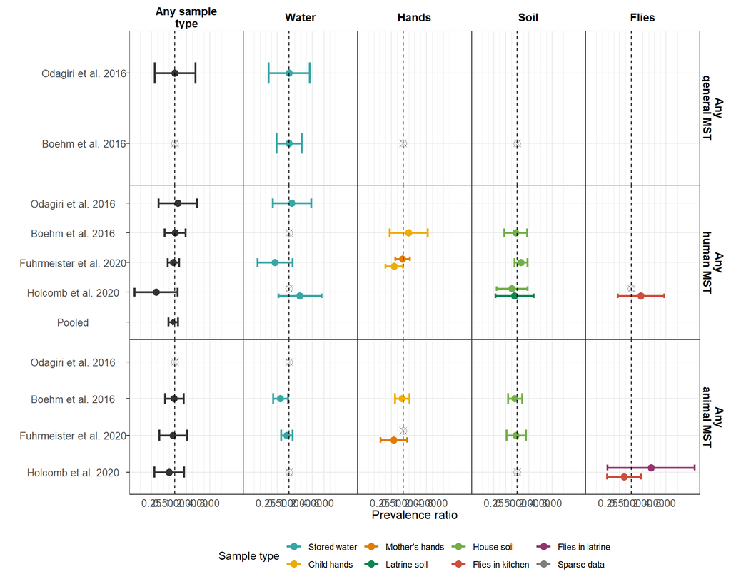

**Figure 1.** Forest plots of intervention effects on any enteropathogen, and any general, human and animal MST markers in different samples of environmental samples.

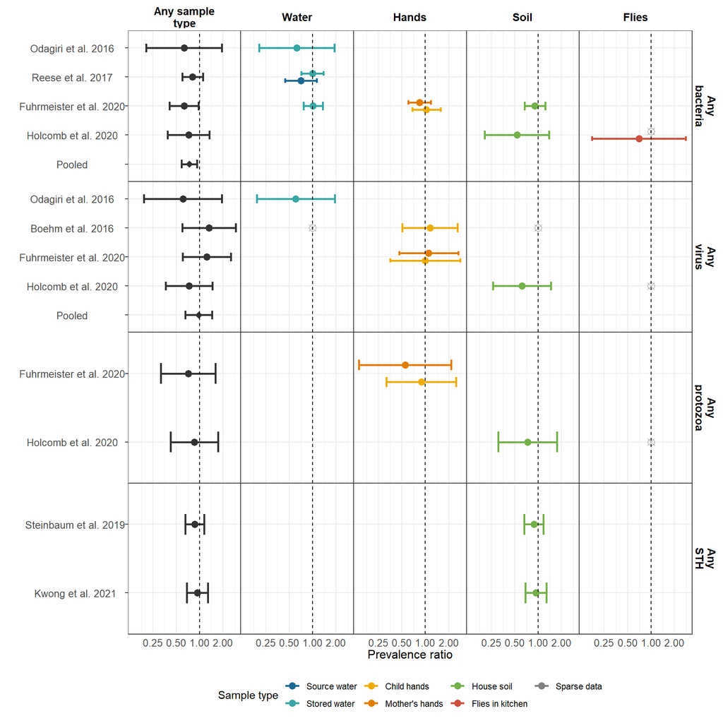

**Figure S1.** Prevalence of any virus, any bacteria, any protozoa and any STH

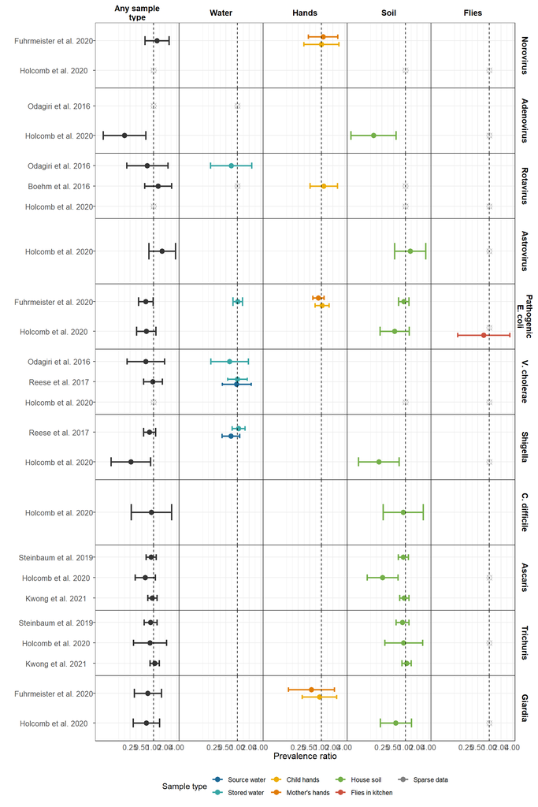

**Figure S3.** Prevalence of specific pathogens

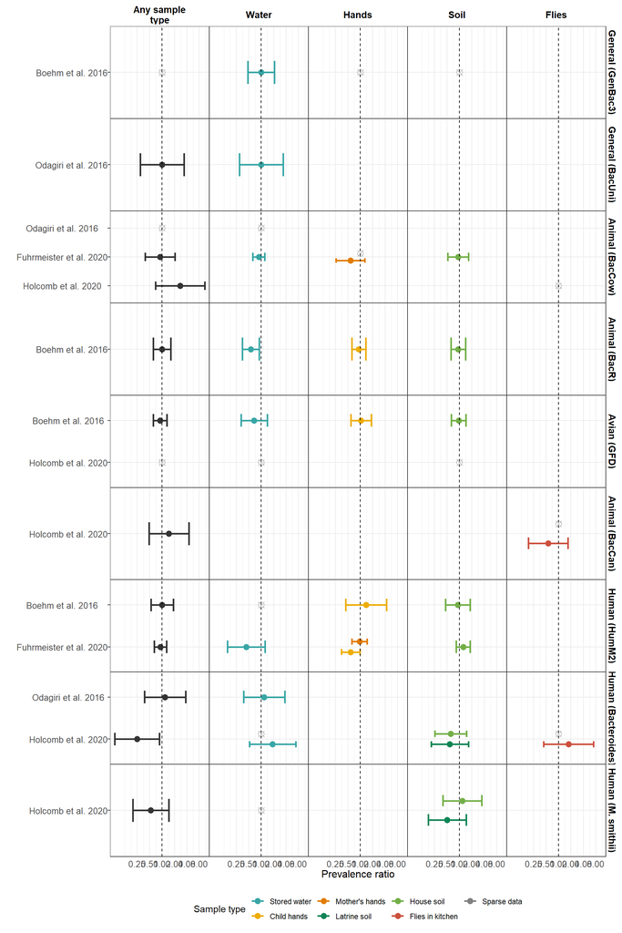

**Figure S4.** Prevalence of specific MST markers

## Abundance table

N’s and percents for ROQ, BLOQ, and BLOD measures, and raw and log10 transformed means and medians of ROQ abundances. P-values are test of normality on raw and log-10 transformed datas (Null hypothesis is normality). The analysis column is my proposed analysis approach.

| study | sample | target | N | mean | med | trans.mean | trans.med | trans.p | raw.p | ROQ | BLOQ | BLOD | Analyze |
| --- | --- | --- | --- | --- | --- | --- | --- | --- | --- | --- | --- | --- | --- |
| Boehm et al. 2016 | any sample type | Animal (BacR) | 497 | 192.3 | 15.0 | 1.5 | 1.2 | 0.00104 | 0.00000 | 2.2 (11) | 20.1 (100) | 77.7 (386) | No |
| Boehm et al. 2016 | any sample type | Avian (GFD) | NA | NA | NA | NA | NA | NA | NA | 0 (0) | 8.2 (41) | 91.8 (456) | No |
| Boehm et al. 2016 | any sample type | General (GenBac3) | 492 | 166449.9 | 111.5 | 2.4 | 2.0 | 0.00000 | 0.00000 | 90.4 (445) | 9.6 (47) | 0 (0) | linear regression - transformed |
| Boehm et al. 2016 | any sample type | Human (HumM2) | 497 | 52.8 | 50.0 | 1.7 | 1.7 | 0.00000 | 0.00000 | 100 (497) | 0 (0) | 0 (0) | linear regression - transformed |
| Boehm et al. 2016 | any sample type | Rotavirus | 497 | 38.2 | 38.2 | 1.5 | 1.5 | NA | NA | 0.4 (2) | 0.2 (1) | 99.4 (494) | No |
| Boehm et al. 2016 | CH | Animal (BacR) | 493 | 18786.2 | 6738.4 | 4.0 | 3.8 | 0.00057 | 0.00000 | 4.5 (22) | 49.7 (245) | 45.8 (226) | No |
| Boehm et al. 2016 | CH | Avian (GFD) | 493 | 6547.6 | 6547.6 | 3.8 | 3.8 | NA | NA | 0.2 (1) | 15.4 (76) | 84.4 (416) | No |
| Boehm et al. 2016 | CH | General (GenBac3) | 493 | 3112091.1 | 355751.0 | 5.6 | 5.6 | 0.00023 | 0.00000 | 98 (483) | 0.6 (3) | 1.4 (7) | linear regression - transformed |
| Boehm et al. 2016 | CH | Human (HumM2) | 482 | 12519.4 | 12519.4 | 4.1 | 4.1 | NA | NA | 0.2 (1) | 0 (0) | 99.8 (481) | No |
| Boehm et al. 2016 | CH | Rotavirus | 493 | 351201.6 | 17277.3 | 4.6 | 4.2 | 0.00575 | 0.00000 | 3.7 (18) | 2.4 (12) | 93.9 (463) | No |
| Boehm et al. 2016 | S | Animal (BacR) | NA | NA | NA | NA | NA | NA | NA | 0 (0) | 29.9 (138) | 70.1 (324) | No |
| Boehm et al. 2016 | S | Avian (GFD) | NA | NA | NA | NA | NA | NA | NA | 0 (0) | 20.4 (100) | 79.6 (390) | No |
| Boehm et al. 2016 | S | Human (HumM2) | 452 | 400.0 | 400.0 | 2.6 | 2.6 | NA | NA | 100 (452) | 0 (0) | 0 (0) | linear regression - transformed |
| Boehm et al. 2016 | S | Rotavirus | 496 | 88981.8 | 57235.3 | 4.8 | 4.7 | 0.81157 | 0.21674 | 0.8 (4) | 0.6 (3) | 98.6 (489) | No |
| Boehm et al. 2016 | W | Animal (BacR) | 493 | 192.3 | 15.0 | 1.5 | 1.2 | 0.00104 | 0.00000 | 2.2 (11) | 19.7 (97) | 78.1 (385) | No |
| Boehm et al. 2016 | W | Avian (GFD) | NA | NA | NA | NA | NA | NA | NA | 0 (0) | 8.1 (40) | 91.9 (453) | No |
| Boehm et al. 2016 | W | General (GenBac3) | 492 | 940.1 | 98.1 | 2.1 | 2.0 | 0.00000 | 0.00000 | 83.9 (413) | 9.6 (47) | 6.5 (32) | linear regression - transformed |
| Boehm et al. 2016 | W | Human (HumM2) | 493 | 50.0 | 50.0 | 1.7 | 1.7 | NA | NA | 0 (0) | 0 (0) | 100 (493) | No |
| Boehm et al. 2016 | W | Rotavirus | 493 | 38.2 | 38.2 | 1.5 | 1.5 | NA | NA | 0.4 (2) | 0.2 (1) | 99.4 (490) | No |
| Steinbaum et al. 2019 | any sample type | Any STH | 2101 | 2.0 | 0.0 | -0.7 | -1.0 | NA | 0.00000 | 100 (2101) | 0 (0) | 0 (0) | negative binomial |
| Steinbaum et al. 2019 | any sample type | Ascaris | 2101 | 1.8 | 0.0 | -0.8 | -1.0 | NA | 0.00000 | 100 (2101) | 0 (0) | 0 (0) | negative binomial |
| Steinbaum et al. 2019 | any sample type | Trichuris | 2102 | 0.2 | 0.0 | -0.9 | -1.0 | NA | 0.00000 | 100 (2102) | 0 (0) | 0 (0) | negative binomial |
| Steinbaum et al. 2019 | S | Any STH | 2101 | 2.0 | 0.0 | -0.7 | -1.0 | NA | 0.00000 | 100 (2101) | 0 (0) | 0 (0) | negative binomial |
| Steinbaum et al. 2019 | S | Ascaris | 2101 | 1.8 | 0.0 | -0.8 | -1.0 | NA | 0.00000 | 100 (2101) | 0 (0) | 0 (0) | negative binomial |
| Steinbaum et al. 2019 | S | Trichuris | 2102 | 0.2 | 0.0 | -0.9 | -1.0 | NA | 0.00000 | 100 (2102) | 0 (0) | 0 (0) | negative binomial |
| Fuhrmeister et al. 2020 | any sample type | Animal (BacCow) | 593 | 77158.1 | 13.3 | 2.3 | 1.1 | 0.00000 | 0.00000 | 100 (593) | 0 (0) | 0 (0) | linear regression - transformed |
| Fuhrmeister et al. 2020 | CH | Animal (BacCow) | 365 | 127640.5 | 6914.8 | 3.5 | 3.8 | 0.00000 | 0.00000 | 100 (365) | 0 (0) | 0 (0) | linear regression - transformed |
| Fuhrmeister et al. 2020 | MH | Animal (BacCow) | 725 | 41933.1 | 5201.9 | 3.2 | 3.7 | 0.00000 | 0.00000 | 100 (725) | 0 (0) | 0 (0) | linear regression - transformed |
| Fuhrmeister et al. 2020 | S | Animal (BacCow) | 631 | 129712.2 | 13.8 | 2.6 | 1.1 | 0.00000 | 0.00000 | 100 (631) | 0 (0) | 0 (0) | linear regression - transformed |
| Fuhrmeister et al. 2020 | W | Animal (BacCow) | 704 | 82.5 | 2.9 | 0.7 | 0.5 | 0.00000 | 0.00000 | 100 (704) | 0 (0) | 0 (0) | linear regression - transformed |
| Holcomb et al. 2020 | any sample type | Avian (GFD) | 64 | 84155.9 | 38078.7 | 4.7 | 4.6 | 0.00000 | 0.00000 | 100 (64) | 0 (0) | 0 (0) | linear regression - transformed |
| Holcomb et al. 2020 | any sample type | Human (Bacteriodes) | 64 | 5002854.1 | 1342181.2 | 6.2 | 6.1 | 0.03360 | 0.00000 | 100 (64) | 0 (0) | 0 (0) | linear regression - transformed |
| Holcomb et al. 2020 | any sample type | Human (M. smithii) | 64 | 2345940.4 | 985579.9 | 6.0 | 6.0 | 0.00003 | 0.00000 | 100 (64) | 0 (0) | 0 (0) | linear regression - transformed |
| Holcomb et al. 2020 | FP | Avian (GFD) | 96 | 152756.6 | 193164.5 | 5.0 | 5.3 | 0.00000 | 0.00000 | 100 (96) | 0 (0) | 0 (0) | linear regression - transformed |
| Holcomb et al. 2020 | FP | Human (Bacteriodes) | 96 | 449443.3 | 162594.8 | 5.4 | 5.2 | 0.00000 | 0.00000 | 100 (96) | 0 (0) | 0 (0) | linear regression - transformed |
| Holcomb et al. 2020 | FP | Human (M. smithii) | 94 | 339551.6 | 240071.9 | 5.5 | 5.4 | 0.00000 | 0.00000 | 100 (94) | 0 (0) | 0 (0) | linear regression - transformed |
| Holcomb et al. 2020 | LS | Avian (GFD) | 60 | 27204.9 | 21178.7 | 4.4 | 4.3 | 0.00000 | 0.00000 | 100 (60) | 0 (0) | 0 (0) | linear regression - transformed |
| Holcomb et al. 2020 | LS | Human (Bacteriodes) | 60 | 15688017.7 | 2954035.4 | 6.5 | 6.5 | 0.00013 | 0.00000 | 100 (60) | 0 (0) | 0 (0) | linear regression - transformed |
| Holcomb et al. 2020 | LS | Human (M. smithii) | 60 | 6868256.8 | 1999243.4 | 6.5 | 6.3 | 0.00000 | 0.00000 | 100 (60) | 0 (0) | 0 (0) | linear regression - transformed |
| Holcomb et al. 2020 | S | Avian (GFD) | 83 | 79290.7 | 38452.9 | 4.7 | 4.6 | 0.00000 | 0.00000 | 100 (83) | 0 (0) | 0 (0) | linear regression - transformed |
| Holcomb et al. 2020 | S | Human (Bacteriodes) | 83 | 7984386.9 | 1679952.8 | 6.4 | 6.2 | 0.00008 | 0.00000 | 100 (83) | 0 (0) | 0 (0) | linear regression - transformed |
| Holcomb et al. 2020 | S | Human (M. smithii) | 83 | 2321772.9 | 1017327.1 | 6.2 | 6.0 | 0.00000 | 0.00000 | 100 (83) | 0 (0) | 0 (0) | linear regression - transformed |
| Holcomb et al. 2020 | SW | Avian (GFD) | 41 | 629.0 | 612.9 | 2.8 | 2.8 | 0.00000 | 0.00000 | 100 (41) | 0 (0) | 0 (0) | linear regression - transformed |
| Holcomb et al. 2020 | SW | Human (Bacteriodes) | 41 | 47160.0 | 34470.2 | 4.6 | 4.5 | 0.00000 | 0.00000 | 100 (41) | 0 (0) | 0 (0) | linear regression - transformed |
| Holcomb et al. 2020 | SW | Human (M. smithii) | 41 | 49980.3 | 45124.9 | 4.7 | 4.7 | 0.00000 | 0.00000 | 100 (41) | 0 (0) | 0 (0) | linear regression - transformed |
| Holcomb et al. 2020 | W | Avian (GFD) | 94 | 613.5 | 576.5 | 2.7 | 2.8 | 0.00000 | 0.00000 | 100 (94) | 0 (0) | 0 (0) | linear regression - transformed |
| Holcomb et al. 2020 | W | Human (Bacteriodes) | 94 | 42252.6 | 21541.3 | 4.4 | 4.3 | 0.00000 | 0.00000 | 100 (94) | 0 (0) | 0 (0) | linear regression - transformed |
| Holcomb et al. 2020 | W | Human (M. smithii) | 94 | 50719.5 | 47918.7 | 4.7 | 4.7 | 0.00000 | 0.00000 | 100 (94) | 0 (0) | 0 (0) | linear regression - transformed |
| Kwong et al. 2021 | any sample type | Any STH | 1396 | 4.1 | 1.5 | 0.1 | 0.2 | NA | 0.00000 | 100 (1396) | 0 (0) | 0 (0) | negative binomial |
| Kwong et al. 2021 | any sample type | Ascaris | 1396 | 2.3 | 0.7 | -0.2 | -0.1 | NA | 0.00000 | 100 (1396) | 0 (0) | 0 (0) | negative binomial |
| Kwong et al. 2021 | any sample type | Trichuris | 1396 | 1.8 | 0.4 | -0.3 | -0.3 | NA | 0.00000 | 100 (1396) | 0 (0) | 0 (0) | negative binomial |
| Kwong et al. 2021 | S | Any STH | 1396 | 4.1 | 1.5 | 0.1 | 0.2 | NA | 0.00000 | 100 (1396) | 0 (0) | 0 (0) | negative binomial |
| Kwong et al. 2021 | S | Ascaris | 1396 | 2.3 | 0.7 | -0.2 | -0.1 | NA | 0.00000 | 100 (1396) | 0 (0) | 0 (0) | negative binomial |
| Kwong et al. 2021 | S | Trichuris | 1396 | 1.8 | 0.4 | -0.3 | -0.3 | NA | 0.00000 | 100 (1396) | 0 (0) | 0 (0) | negative binomial |

## QA check tables

| study | Any pathogen | Norovirus | Adenovirus | Rotavirus | Astrovirus | Sapovirus | Pan enterovirus | Pathogenic E. coli | Yersinia | V. cholerae | Shigella | C. difficile | Salmonella | Campylobacter | Any STH | Ascaris | Trichuris | Giardia | Cryptosporidium | Entamoeba histolytica |
| --- | --- | --- | --- | --- | --- | --- | --- | --- | --- | --- | --- | --- | --- | --- | --- | --- | --- | --- | --- | --- |
| Odagiri et al. 2016 | 27/60 | NA | 5/60 | 14/60 | NA | NA | NA | NA | NA | 19/60 | NA | NA | NA | NA | NA | NA | NA | NA | NA | NA |
| Boehm et al. 2016 | 38/1482 | NA | NA | 38/1482 | NA | NA | NA | NA | NA | NA | NA | NA | NA | NA | NA | NA | NA | NA | NA | NA |
| Reese et al. 2017 | 471/3452 | NA | NA | NA | NA | NA | NA | NA | NA | 136/698 | 351/3373 | NA | NA | NA | NA | NA | NA | NA | NA | NA |
| Steinbaum et al. 2019 | 382/2107 | NA | NA | NA | NA | NA | NA | NA | NA | NA | NA | NA | NA | NA | 376/2107 | 273/2107 | 146/2107 | NA | NA | NA |
| Fuhrmeister et al. 2020 | 1092/2595 | 35/1021 | NA | NA | NA | NA | NA | 1043/2590 | NA | NA | NA | NA | NA | NA | NA | NA | NA | 29/913 | NA | NA |
| Holcomb et al. 2020 | 247/355 | 15/355 | 53/355 | 18/355 | 50/355 | 1/355 | 4/176 | 164/355 | 7/179 | 5/355 | 49/355 | 26/179 | 9/179 | 19/355 | NA | 112/355 | 53/355 | 77/355 | 13/179 | 3/179 |
| Kwong et al. 2021 | 1050/1396 | NA | NA | NA | NA | NA | NA | NA | NA | NA | NA | NA | NA | NA | 1050/1396 | 871/1396 | 786/1396 | NA | NA | NA |

| study | Any virus | Norovirus | Adenovirus | Rotavirus | Astrovirus | Sapovirus | Pan enterovirus |
| --- | --- | --- | --- | --- | --- | --- | --- |
| Odagiri et al. 2016 | 17/60 | NA | 5/60 | 14/60 | NA | NA | NA |
| Boehm et al. 2016 | 38/1482 | NA | NA | 38/1482 | NA | NA | NA |
| Fuhrmeister et al. 2020 | 35/1021 | 35/1021 | NA | NA | NA | NA | NA |
| Holcomb et al. 2020 | 107/355 | 15/355 | 53/355 | 18/355 | 50/355 | 1/355 | 4/176 |

| study | Any protozoa | Giardia | Cryptosporidium | Entamoeba histolytica |
| --- | --- | --- | --- | --- |
| Fuhrmeister et al. 2020 | 29/913 | 29/913 | NA | NA |
| Holcomb et al. 2020 | 87/355 | 77/355 | 13/179 | 3/179 |

| study | Any bacteria | Pathogenic E. coli | Yersinia | V. cholerae | Shigella | C. difficile | Salmonella | Campylobacter |
| --- | --- | --- | --- | --- | --- | --- | --- | --- |
| Odagiri et al. 2016 | 19/60 | NA | NA | 19/60 | NA | NA | NA | NA |
| Reese et al. 2017 | 471/3452 | NA | NA | 136/698 | 351/3373 | NA | NA | NA |
| Fuhrmeister et al. 2020 | 1043/2590 | 1043/2590 | NA | NA | NA | NA | NA | NA |
| Holcomb et al. 2020 | 195/355 | 164/355 | 7/179 | 5/355 | 49/355 | 26/179 | 9/179 | 19/355 |

| study | Any general MST | General (GenBac3) | General (BacUni) |
| --- | --- | --- | --- |
| Odagiri et al. 2016 | 46/60 | NA | 46/60 |
| Boehm et al. 2016 | 1443/1482 | 1443/1482 | NA |

| study | Any human MST | Human (HumM2) | Human (Bacteroides) | Human (M. smithii) |
| --- | --- | --- | --- | --- |
| Odagiri et al. 2016 | 43/60 | NA | 43/60 | NA |
| Boehm et al. 2016 | 56/1482 | 56/1482 | NA | NA |
| Fuhrmeister et al. 2020 | 336/2271 | 336/2271 | NA | NA |
| Holcomb et al. 2020 | 340/902 | NA | 273/902 | 110/721 |

| study | Any animal MST | Animal (BacCow) | Animal (BacR) | Avian (GFD) | Animal (BacCan) |
| --- | --- | --- | --- | --- | --- |
| Odagiri et al. 2016 | 55/60 | 55/60 | NA | NA | NA |
| Boehm et al. 2016 | 792/1482 | NA | 704/1482 | 293/1482 | NA |
| Fuhrmeister et al. 2020 | 2112/2426 | 2112/2426 | NA | NA | NA |
| Holcomb et al. 2020 | 87/902 | 32/176 | NA | 12/726 | 62/176 |

## Tables

#### Any pathogens + specific pathogens prevalences (N) and mean abundances by study

| study | target | prev_any sample type | prev_CH | prev_MH | prev_S | prev_SW | prev_W | abund_any sample type | abund_CH | abund_MH | abund_S | abund_SW | abund_W |
| --- | --- | --- | --- | --- | --- | --- | --- | --- | --- | --- | --- | --- | --- |
| Fuhrmeister et al. 2020 | Norovirus | 0.1% (495) | 0% (337) | 0% (684) |  |  |  |  |  |  |  |  |  |
| Holcomb et al. 2020 | Norovirus | 0% (88) |  |  | 0% (88) |  |  |  |  |  |  |  |  |
| Odagiri et al. 2016 | Adenovirus | 1% (1) |  |  |  |  | 0.1% (60) |  |  |  |  |  |  |
| Holcomb et al. 2020 | Adenovirus | 0.2% (88) |  |  | 0.2% (88) |  |  |  |  |  |  |  |  |
| Odagiri et al. 2016 | Rotavirus | 1% (1) |  |  |  |  | 0.2% (60) |  |  |  |  |  |  |
| Boehm et al. 2016 | Rotavirus | 0.1% (497) | 0.1% (492) |  | 0% (496) |  | 0% (493) | 53.1 | 12979.9 |  | 1122.8 |  | 50.3 |
| Holcomb et al. 2020 | Rotavirus | 0% (88) |  |  | 0% (88) |  |  |  |  |  |  |  |  |
| Holcomb et al. 2020 | Astrovirus | 0.3% (88) |  |  | 0.3% (88) |  |  |  |  |  |  |  |  |
| Holcomb et al. 2020 | Sapovirus | 0% (88) |  |  | 0% (88) |  |  |  |  |  |  |  |  |
| Fuhrmeister et al. 2020 | Pathogenic E. coli | 0.8% (595) | 0.3% (373) | 0.2% (737) | 0.6% (739) |  | 0.4% (741) |  |  |  |  |  |  |
| Holcomb et al. 2020 | Yersinia | 0% (88) |  |  | 0% (88) |  |  |  |  |  |  |  |  |
| Odagiri et al. 2016 | V. cholerae | 1% (1) |  |  |  |  | 0.3% (60) |  |  |  |  |  |  |
| Reese et al. 2017 | V. cholerae | 0.7% (89) |  |  |  | 0.1% (276) | 0.2% (422) |  |  |  |  |  |  |
| Holcomb et al. 2020 | V. cholerae | 0% (88) |  |  | 0% (88) |  |  |  |  |  |  |  |  |
| Reese et al. 2017 | Shigella | 0.9% (90) |  |  |  | 0.1% (1499) | 0.1% (1874) |  |  |  |  |  |  |
| Holcomb et al. 2020 | Shigella | 0.2% (88) |  |  | 0.2% (88) |  |  |  |  |  |  |  |  |
| Holcomb et al. 2020 | C. difficile | 0.1% (88) |  |  | 0.1% (88) |  |  |  |  |  |  |  |  |
| Holcomb et al. 2020 | Salmonella | 0.1% (88) |  |  | 0.1% (88) |  |  |  |  |  |  |  |  |
| Holcomb et al. 2020 | Campylobacter jejuni/coli | 0.1% (88) |  |  | 0.1% (88) |  |  |  |  |  |  |  |  |
| Steinbaum et al. 2019 | Any STH | 0.2% (2107) |  |  | 0.2% (2107) |  |  | 2 |  |  | 2 |  |  |
| Kwong et al. 2021 | Any STH | 0.8% (1396) |  |  | 0.8% (1396) |  |  | 4.1 |  |  | 4.1 |  |  |
| Steinbaum et al. 2019 | Ascaris | 0.1% (2107) |  |  | 0.1% (2107) |  |  | 1.8 |  |  | 1.8 |  |  |
| Holcomb et al. 2020 | Ascaris | 0.6% (88) |  |  | 0.6% (88) |  |  |  |  |  |  |  |  |
| Kwong et al. 2021 | Ascaris | 0.6% (1396) |  |  | 0.6% (1396) |  |  | 2.3 |  |  | 2.3 |  |  |
| Steinbaum et al. 2019 | Trichuris | 0.1% (2107) |  |  | 0.1% (2107) |  |  | 0.2 |  |  | 0.2 |  |  |
| Holcomb et al. 2020 | Trichuris | 0.2% (88) |  |  | 0.2% (88) |  |  |  |  |  |  |  |  |
| Kwong et al. 2021 | Trichuris | 0.6% (1396) |  |  | 0.6% (1396) |  |  | 1.8 |  |  | 1.8 |  |  |
| Fuhrmeister et al. 2020 | Giardia | 0.1% (463) | 0% (311) | 0% (602) |  |  |  |  |  |  |  |  |  |
| Holcomb et al. 2020 | Giardia | 0.3% (88) |  |  | 0.3% (88) |  |  |  |  |  |  |  |  |
| Holcomb et al. 2020 | Cryptosporidium | 0.1% (88) |  |  | 0.1% (88) |  |  |  |  |  |  |  |  |
| Holcomb et al. 2020 | Entamoeba histolytica | 0% (88) |  |  | 0% (88) |  |  |  |  |  |  |  |  |

#### Any virus + specific virus prevalences (N) and mean abundances by study

| study | target | prev_any sample type | prev_CH | prev_MH | prev_S | prev_W | abund_any sample type | abund_CH | abund_MH | abund_S | abund_W |
| --- | --- | --- | --- | --- | --- | --- | --- | --- | --- | --- | --- |
| Fuhrmeister et al. 2020 | Norovirus | 0.1% (495) | 0% (337) | 0% (684) |  |  |  |  |  |  |  |
| Holcomb et al. 2020 | Norovirus | 0% (88) |  |  | 0% (88) |  |  |  |  |  |  |
| Odagiri et al. 2016 | Adenovirus | 1% (1) |  |  |  | 0.1% (60) |  |  |  |  |  |
| Holcomb et al. 2020 | Adenovirus | 0.2% (88) |  |  | 0.2% (88) |  |  |  |  |  |  |
| Odagiri et al. 2016 | Rotavirus | 1% (1) |  |  |  | 0.2% (60) |  |  |  |  |  |
| Boehm et al. 2016 | Rotavirus | 0.1% (497) | 0.1% (492) |  | 0% (496) | 0% (493) | 53.1 | 12979.9 |  | 1122.8 | 50.3 |
| Holcomb et al. 2020 | Rotavirus | 0% (88) |  |  | 0% (88) |  |  |  |  |  |  |
| Holcomb et al. 2020 | Astrovirus | 0.3% (88) |  |  | 0.3% (88) |  |  |  |  |  |  |
| Holcomb et al. 2020 | Sapovirus | 0% (88) |  |  | 0% (88) |  |  |  |  |  |  |

#### Any bacteria + specific bacteria prevalences (N) and mean abundances by study

| study | target | prev_any sample type | prev_CH | prev_MH | prev_S | prev_SW | prev_W | abund_any sample type | abund_CH | abund_MH | abund_S | abund_SW | abund_W |
| --- | --- | --- | --- | --- | --- | --- | --- | --- | --- | --- | --- | --- | --- |
| Fuhrmeister et al. 2020 | Pathogenic E. coli | 0.8% (595) | 0.3% (373) | 0.2% (737) | 0.6% (739) |  | 0.4% (741) |  |  |  |  |  |  |
| Holcomb et al. 2020 | Yersinia | 0% (88) |  |  | 0% (88) |  |  |  |  |  |  |  |  |
| Odagiri et al. 2016 | V. cholerae | 1% (1) |  |  |  |  | 0.3% (60) |  |  |  |  |  |  |
| Reese et al. 2017 | V. cholerae | 0.7% (89) |  |  |  | 0.1% (276) | 0.2% (422) |  |  |  |  |  |  |
| Holcomb et al. 2020 | V. cholerae | 0% (88) |  |  | 0% (88) |  |  |  |  |  |  |  |  |
| Reese et al. 2017 | Shigella | 0.9% (90) |  |  |  | 0.1% (1499) | 0.1% (1874) |  |  |  |  |  |  |
| Holcomb et al. 2020 | Shigella | 0.2% (88) |  |  | 0.2% (88) |  |  |  |  |  |  |  |  |
| Holcomb et al. 2020 | C. difficile | 0.1% (88) |  |  | 0.1% (88) |  |  |  |  |  |  |  |  |
| Holcomb et al. 2020 | Salmonella | 0.1% (88) |  |  | 0.1% (88) |  |  |  |  |  |  |  |  |
| Holcomb et al. 2020 | Campylobacter jejuni/coli | 0.1% (88) |  |  | 0.1% (88) |  |  |  |  |  |  |  |  |

#### Any helminth + specific helminth prevalences (N) and mean abundances by study

| study | target | prev_any sample type | prev_S | abund_any sample type | abund_S |
| --- | --- | --- | --- | --- | --- |
| Steinbaum et al. 2019 | Any STH | 0.2% (2107) | 0.2% (2107) | 2 | 2 |
| Kwong et al. 2021 | Any STH | 0.8% (1396) | 0.8% (1396) | 4.1 | 4.1 |
| Steinbaum et al. 2019 | Ascaris | 0.1% (2107) | 0.1% (2107) | 1.8 | 1.8 |
| Holcomb et al. 2020 | Ascaris | 0.6% (88) | 0.6% (88) |  |  |
| Kwong et al. 2021 | Ascaris | 0.6% (1396) | 0.6% (1396) | 2.3 | 2.3 |
| Steinbaum et al. 2019 | Trichuris | 0.1% (2107) | 0.1% (2107) | 0.2 | 0.2 |
| Holcomb et al. 2020 | Trichuris | 0.2% (88) | 0.2% (88) |  |  |
| Kwong et al. 2021 | Trichuris | 0.6% (1396) | 0.6% (1396) | 1.8 | 1.8 |

#### Any protozoa + specific protozoa prevalences (N) and mean abundances by study

| study | target | prev_any sample type | prev_CH | prev_MH | prev_S | abund_any sample type | abund_CH | abund_MH | abund_S |
| --- | --- | --- | --- | --- | --- | --- | --- | --- | --- |
| Fuhrmeister et al. 2020 | Giardia | 0.1% (463) | 0% (311) | 0% (602) |  |  |  |  |  |
| Holcomb et al. 2020 | Giardia | 0.3% (88) |  |  | 0.3% (88) |  |  |  |  |
| Holcomb et al. 2020 | Cryptosporidium | 0.1% (88) |  |  | 0.1% (88) |  |  |  |  |
| Holcomb et al. 2020 | Entamoeba histolytica | 0% (88) |  |  | 0% (88) |  |  |  |  |

#### Any general MST + specific general MST prevalences (N) and mean abundances by study

| study | target | prev_any sample type | prev_CH | prev_S | prev_W | abund_any sample type | abund_CH | abund_S | abund_W |
| --- | --- | --- | --- | --- | --- | --- | --- | --- | --- |
| Boehm et al. 2016 | General (GenBac3) | 1% (497) | 1% (493) | 1% (496) | 0.9% (493) | 150570.7 | 3048970.7 |  | 813.9 |
| Odagiri et al. 2016 | General (BacUni) | 1% (1) |  |  | 0.8% (60) |  |  |  |  |

#### Any animal MST + specific animal MST prevalences (N) and mean abundances by study

| study | target | prev_any sample type | prev_CH | prev_FP | prev_LS | prev_MH | prev_S | prev_SW | prev_W | abund_any sample type | abund_CH | abund_FP | abund_LS | abund_MH | abund_S | abund_SW | abund_W |
| --- | --- | --- | --- | --- | --- | --- | --- | --- | --- | --- | --- | --- | --- | --- | --- | --- | --- |
| Odagiri et al. 2016 | Animal (BacCow) | 1% (1) |  |  |  |  |  |  | 0.9% (60) |  |  |  |  |  |  |  |  |
| Fuhrmeister et al. 2020 | Animal (BacCow) | 1% (594) | 1% (365) |  |  | 1% (726) | 0.9% (631) |  | 0.7% (704) | 77158.1 | 127640.5 |  |  | 41933.1 | 129712.2 |  | 82.5 |
| Boehm et al. 2016 | Animal (BacR) | 0.8% (497) | 0.5% (492) |  |  |  | 0.7% (496) |  | 0.2% (493) | 98.6 | 1177.3 |  |  |  | 818.2 |  | 87.6 |
| Boehm et al. 2016 | Avian (GFD) | 0.5% (497) | 0.2% (492) |  |  |  | 0.3% (496) |  | 0.1% (493) | 69.7 | 205.6 |  |  |  | 685.7 |  | 64.2 |
| Holcomb et al. 2020 | Avian (GFD) | 0.1% (64) |  | 0% (96) | 0% (60) |  | 0% (83) | 0% (41) | 0% (94) | 3 |  | 3.2 | 2.7 |  | 3 | 1.9 | 1.9 |

#### Any human MST + specific human MST prevalences (N) and mean abundances by study

| study | target | prev_any sample type | prev_CH | prev_FP | prev_LS | prev_MH | prev_S | prev_SW | prev_W | abund_any sample type | abund_CH | abund_FP | abund_LS | abund_MH | abund_S | abund_SW | abund_W |
| --- | --- | --- | --- | --- | --- | --- | --- | --- | --- | --- | --- | --- | --- | --- | --- | --- | --- |
| Boehm et al. 2016 | Human (HumM2) | 0.1% (497) | 0% (492) |  |  |  | 0.1% (496) |  | 0% (493) | 52.8 | 150.8 |  |  |  | 400 |  | 50 |
| Fuhrmeister et al. 2020 | Human (HumM2) | 0.4% (592) | 0.2% (338) |  |  | 0.2% (651) | 0.2% (631) |  | 0% (651) |  |  |  |  |  |  |  |  |
| Holcomb et al. 2020 | Human (M. smithii) | 0.5% (64) |  | 0% (94) | 0.4% (60) |  | 0.2% (83) | 0% (41) | 0% (94) | 4 |  | 3.5 | 4.5 |  | 4.2 | 2.9 | 3 |